# Calssification in R

# Introduction

Machine learning is the fascinating field of building models to learn from data and then to predict unseen data which has shown more and more promising results.

Classification is the most widely used machine learning technique. The basic idea is to build a classifier which learns from training observations with discrete classes and then is applied to predict the outcome for new observations. There most common example we have seen everyday is probably the spam or junk mail filter in the email system which is telling you whether the email is a junk mail or not.

### Load the libraries

```r
library(mlbench)              # datasets
library(class)                # knn
library(caret)
library(e1071)                # svm
library(MASS)                 # lda
```

### Load the dataset

```r
data("Ionosphere")
str(Ionosphere)
```

```
## 'data.frame':    351 obs. of  35 variables:
##  $ V1   : Factor w/ 2 levels "0","1": 2 2 2 2 2 2 2 1 2 2 ...
##  $ V2   : Factor w/ 1 level "0": 1 1 1 1 1 1 1 1 1 1 ...
##  $ V3   : num  0.995 1 1 1 1 ...
##  $ V4   : num  -0.0589 -0.1883 -0.0336 -0.4516 -0.024 ...
##  $ V5   : num  0.852 0.93 1 1 0.941 ...
##  $ V6   : num  0.02306 -0.36156 0.00485 1 0.06531 ...
##  $ V7   : num  0.834 -0.109 1 0.712 0.921 ...
##  $ V8   : num  -0.377 -0.936 -0.121 -1 -0.233 ...
##  $ V9   : num  1 1 0.89 0 0.772 ...
##  $ V10  : num  0.0376 -0.0455 0.012 0 -0.164 ...
##  $ V11  : num  0.852 0.509 0.731 0 0.528 ...
##  $ V12  : num  -0.1776 -0.6774 0.0535 0 -0.2028 ...
##  $ V13  : num  0.598 0.344 0.854 0 0.564 ...
##  $ V14  : num  -0.44945 -0.69707 0.00827 0 -0.00712 ...
```

[output cut: 21 more lines]

```r
summary(Ionosphere)
```

```
##  V1      V2            V3                V4                 V5
##  0: 38   0:351   Min.   :-1.0000   Min.   :-1.00000   Min.   :-1.0000
##  1:313           1st Qu.: 0.4721   1st Qu.:-0.06474   1st Qu.: 0.4127
##                  Median : 0.8711   Median : 0.01631   Median : 0.8092
##                  Mean   : 0.6413   Mean   : 0.04437   Mean   : 0.6011
##                  3rd Qu.: 1.0000   3rd Qu.: 0.19418   3rd Qu.: 1.0000
##                  Max.   : 1.0000   Max.   : 1.00000   Max.   : 1.0000
##        V6                V7                V8                 V9
##  Min.   :-1.0000   Min.   :-1.0000   Min.   :-1.00000   Min.   :-1.00000
##  1st Qu.:-0.0248   1st Qu.: 0.2113   1st Qu.:-0.05484   1st Qu.: 0.08711
##  Median : 0.0228   Median : 0.7287   Median : 0.01471   Median : 0.68421
##  Mean   : 0.1159   Mean   : 0.5501   Mean   : 0.11936   Mean   : 0.51185
##  3rd Qu.: 0.3347   3rd Qu.: 0.9692   3rd Qu.: 0.44567   3rd Qu.: 0.95324
##  Max.   : 1.0000   Max.   : 1.0000   Max.   : 1.00000   Max.   : 1.00000
##       V10                V11                V12
##  Min.   :-1.00000   Min.   :-1.00000   Min.   :-1.00000
##  1st Qu.:-0.04807   1st Qu.: 0.02112   1st Qu.:-0.06527
##  Median : 0.01829   Median : 0.66798   Median : 0.02825
##  Mean   : 0.18135   Mean   : 0.47618   Mean   : 0.15504
##  3rd Qu.: 0.53419   3rd Qu.: 0.95790   3rd Qu.: 0.48237
##  Max.   : 1.00000   Max.   : 1.00000   Max.   : 1.00000
##       V13               V14                V15               V16
##  Min.   :-1.0000   Min.   :-1.00000   Min.   :-1.0000   Min.   :-1.00000
##  1st Qu.: 0.0000   1st Qu.:-0.07372   1st Qu.: 0.0000   1st Qu.:-0.08170
##  Median : 0.6441   Median : 0.03027   Median : 0.6019   Median : 0.00000
##  Mean   : 0.4008   Mean   : 0.09341   Mean   : 0.3442   Mean   : 0.07113
##  3rd Qu.: 0.9555   3rd Qu.: 0.37486   3rd Qu.: 0.9193   3rd Qu.: 0.30897
##  Max.   : 1.0000   Max.   : 1.00000   Max.   : 1.0000   Max.   : 1.00000
##       V17               V18                 V19
##  Min.   :-1.0000   Min.   :-1.000000   Min.   :-1.0000
##  1st Qu.: 0.0000   1st Qu.:-0.225690   1st Qu.: 0.0000
##  Median : 0.5909   Median : 0.000000   Median : 0.5762
##  Mean   : 0.3819   Mean   :-0.003617   Mean   : 0.3594
##  3rd Qu.: 0.9357   3rd Qu.: 0.195285   3rd Qu.: 0.8993
##  Max.   : 1.0000   Max.   : 1.000000   Max.   : 1.0000
##       V20                V21               V22
##  Min.   :-1.00000   Min.   :-1.0000   Min.   :-1.000000
##  1st Qu.:-0.23467   1st Qu.: 0.0000   1st Qu.:-0.243870
##  Median : 0.00000   Median : 0.4991   Median : 0.000000
##  Mean   :-0.02402   Mean   : 0.3367   Mean   : 0.008296
```

[output cut: 15 more lines]

```
##  Max.   : 1.0000   Max.   : 1.00000   Max.   : 1.0000   Max.   : 1.00000
##       V31               V32                 V33
##  Min.   :-1.0000   Min.   :-1.000000   Min.   :-1.0000
##  1st Qu.: 0.0000   1st Qu.:-0.242595   1st Qu.: 0.0000
##  Median : 0.4428   Median : 0.000000   Median : 0.4096
##  Mean   : 0.3525   Mean   :-0.003794   Mean   : 0.3494
##  3rd Qu.: 0.8576   3rd Qu.: 0.200120   3rd Qu.: 0.8138
##  Max.   : 1.0000   Max.   : 1.000000   Max.   : 1.0000
##       V34            Class
##  Min.   :-1.00000   bad :126
##  1st Qu.:-0.16535   good:225
##  Median : 0.00000
##  Mean   : 0.01448
##  3rd Qu.: 0.17166
##  Max.   : 1.00000
```

```r
apply(Ionosphere, 2, var)
```

```
##         V1         V2         V3         V4         V5         V6
## 0.09681726 0.00000000 0.24771345 0.19486466 0.27025599 0.21234597
##         V7         V8         V9        V10        V11        V12
## 0.24270774 0.27118045 0.25711545 0.23411168 0.31752815 0.24484431
##        V13        V14        V15        V16        V17        V18
## 0.38711557 0.24489893 0.42618418 0.21010367 0.38194916 0.24677247
##        V19        V20        V21        V22        V23        V24
## 0.39221012 0.26943999 0.37189058 0.26849589 0.36453518 0.27821017
##        V25        V26        V27        V28        V29        V30
## 0.33460543 0.25856666 0.26646726 0.30252777 0.33164418 0.25803769
##        V31        V32        V33        V34      Class
## 0.32659324 0.26375862 0.27317700 0.21933975         NA
```

## Training and test set split

We can’t use the train error to measure the performance of the model on the unseen data. One approach is called train/test split which will hold out a subset of data as the test set to estimate how well the generalization of the model. Another more robust approach is cross-validation which will divide the data set into `k` fold and each time it will hold out one fold for test and train withe rest. It gives you multiple estimate of out-of-sample errors.

It is important to shuffle the samples before the split. Generally we can split training and test set into 7/3.

```r
set.seed(1)
df <- Ionosphere[, -c(1, 2)]
ix_shuffled <- sample(1:nrow(df), size=nrow(df), replace=F)
ix_train <- ix_shuffled[1:round(0.7 * nrow(df))]
df_train <- df[ix_train, ]
df_test <- df[-ix_train, ]
```

Alternatively, we can utilize the createDataPartition function from caret library.

```r
ixTrain <- createDataPartition(df$Class, p=0.7)
```

## SVM (Support Vector Machines) model

The basic idea of SVM model is to find the hyperplane that can seperate the classes in the feature space while maximizing the margain (or gap) between classes. If the feature space can’t be separated by linear boundary, we can enlarge the feature space through kernel tricks (namely polynomial kernel, radial kernel, etc.) to make it linear separable. SVM model is implemented in the library e1071.

```r
library(e1071)
```

### SVM model with linear kernel

```r
svm_model1 <- svm(Class ~ ., data=df_train, kernel="linear", type="C-classification")
svm_pred1 <- predict(svm_model1, df_test)
```

### Model performance metrics

We define a function to obtain various performance metrics for the classification model. * Accuracy * Precision * Recall * F1 score

```r
classification_metrics <- function(truth, pred, pos_label=NULL) {
  if (length(unique(truth)) == 2 & is.null(pos_label)) {
    stop("pos_label must not NULL")
  }
  else if (length(unique(truth)) == 2) {
    conf <- table(truth, pred)
    acc <- sum(diag(conf)) / sum(conf)
    pos_ix <- which(colnames(conf) == pos_label)
    TP <- conf[pos_ix, pos_ix]
    TN <- conf[-pos_ix, -pos_ix]
    FP <- conf[-pos_ix, pos_ix]
    FN <- conf[pos_ix, -pos_ix]
    precision <- TP / (TP + FP)
    recall <- TP / (TP + FN)
    F1_score <- 2*TP / (2*TP + FP + FN)
    metrics <- list(accuracy=acc, precision=precision, recall=recall, F1_score=F1_score, TP=TP, TN=TN, FP=FP, FN=FN)
  }
}
```

```r
svm_metrics1 <- classification_metrics(df_test$Class, svm_pred1, pos_label="good")
cat(c("Accuracy:", round(svm_metrics1$accuracy, digits = 3)))
```

```
## Accuracy: 0.857
```

```r
cat(c("Precision:", round(svm_metrics1$precision, digits = 3)))
```

```
## Precision: 0.84
```

```r
cat(c("Recall:", round(svm_metrics1$recall, digits = 3)))
```

```
## Recall: 0.971
```

```r
cat(c("F1 score:", round(svm_metrics1$F1_score, digits = 3)))
```

```
## F1 score: 0.901
```

### SVM model with polynomial kernel

```r
svm_model2 <- svm(Class ~ ., data=df_train, kernel="polynomial", type="C-classification")
svm_pred2 <- predict(svm_model2, df_test)
```

### Model performance metrics

```r
svm_metrics2 <- classification_metrics(df_test$Class, svm_pred2, pos_label="good")
cat(c("Accuracy:", round(svm_metrics2$accuracy, digits = 3)))
```

```
## Accuracy: 0.743
```

```r
cat(c("Precision:", round(svm_metrics2$precision, digits = 3)))
```

```
## Precision: 0.722
```

```r
cat(c("Recall:", round(svm_metrics2$recall, digits = 3)))
```

```
## Recall: 1
```

```r
cat(c("F1 score:", round(svm_metrics2$F1_score, digits = 3)))
```

```
## F1 score: 0.838
```

### SVM model with RBF kernel

```r
svm_model3 <- svm(Class ~ ., data=df_train, kernel="radial", type="C-classification")
svm_pred3 <- predict(svm_model3, df_test)
```

### Model performance metrics

```r
svm_metrics3 <- classification_metrics(df_test$Class, svm_pred3, pos_label="good")
cat(c("Accuracy:", round(svm_metrics3$accuracy, digits = 3)))
```

```
## Accuracy: 0.962
```

```r
cat(c("Precision:", round(svm_metrics3$precision, digits = 3)))
```

```
## Precision: 0.946
```

```r
cat(c("Recall:", round(svm_metrics3$recall, digits = 3)))
```

```
## Recall: 1
```

```r
cat(c("F1 score:", round(svm_metrics3$F1_score, digits = 3)))
```

```
## F1 score: 0.972
```

## kNN (k-Nearest Neighbours) model

kNN is an instance-based learning method, also knows as non-parametric lazy learning algorithm. It is because unlike most of the algorithms which are required to learn the weights (parameters) of the model during training process, kNN just stores the training samples and make prediction for unseen data by comparing them to the training set with a given distance metric.

```r
knn_pred1 <- knn(train=df_train[, -33], test=df_test[, -33], cl=df_train$Class, k=3)
```

### Model performance metrics

```r
knn_metrics1 <- classification_metrics(df_test$Class, knn_pred1, pos_label="good")
cat(c("Accuracy:", round(knn_metrics1$accuracy, digits = 3)))
```

```
## Accuracy: 0.886
```

```r
cat(c("Precision:", round(knn_metrics1$precision, digits = 3)))
```

```
## Precision: 0.872
```

```r
cat(c("Recall:", round(knn_metrics1$recall, digits = 3)))
```

```
## Recall: 0.971
```

```r
cat(c("F1 score:", round(knn_metrics1$F1_score, digits = 3)))
```

```
## F1 score: 0.919
```

## Logistic Regression model

```r
lr_model1 <- glm(Class ~ ., data=df_train, family=binomial(link="logit"))
summary(lr_model1)
```

```
##
## Call:
## glm(formula = Class ~ ., family = binomial(link = "logit"), data = df_train)
##
## Deviance Residuals:
##      Min        1Q    Median        3Q       Max
## -2.44678  -0.02458   0.14227   0.25056   3.09964
##
## Coefficients:
##             Estimate Std. Error z value Pr(>|z|)
## (Intercept) -3.02337    0.85653  -3.530 0.000416 ***
## V3           3.03546    1.37387   2.209 0.027145 *
## V4           0.70425    1.28285   0.549 0.583023
## V5           4.65601    1.59434   2.920 0.003497 **
## V6           1.02496    1.17410   0.873 0.382676
## V7          -0.67795    1.60597  -0.422 0.672921
## V8           2.92335    1.22464   2.387 0.016981 *
## V9           2.91493    1.76762   1.649 0.099133 .
## V10          0.07374    1.16056   0.064 0.949339
## V11         -2.92214    1.32980  -2.197 0.027990 *
## V12         -1.83268    1.30877  -1.400 0.161423
## V13         -3.58975    1.51941  -2.363 0.018147 *
## V14          2.71281    0.93341   2.906 0.003657 **
## V15          4.22571    1.51093   2.797 0.005162 **
## V16         -1.69769    1.15148  -1.474 0.140385
## V17          2.66534    1.16527   2.287 0.022177 *
## V18          0.43937    0.95543   0.460 0.645613
## V19         -1.00682    1.79602  -0.561 0.575083
## V20         -0.39761    1.50112  -0.265 0.791105
## V21         -1.08367    1.72683  -0.628 0.530301
## V22         -5.17264    1.31617  -3.930 8.49e-05 ***
## V23          1.99893    1.47628   1.354 0.175724
## V24          1.62921    0.92942   1.753 0.079614 .
## V25         -1.39626    1.29919  -1.075 0.282500
## V26          2.62525    1.00923   2.601 0.009289 **
## V27         -7.25542    1.69042  -4.292 1.77e-05 ***
## V28         -0.07145    1.30871  -0.055 0.956463
## V29          4.68488    1.58583   2.954 0.003135 **
## V30          0.83496    1.05992   0.788 0.430838
## V31          1.38358    1.06479   1.299 0.193808
## V32         -0.17269    1.38430  -0.125 0.900721
## V33         -0.26260    1.49786  -0.175 0.860829
## V34         -1.07487    0.98661  -1.089 0.275949
## ---
## Signif. codes:  0 '***' 0.001 '**' 0.01 '*' 0.05 '.' 0.1 ' ' 1
##
## (Dispersion parameter for binomial family taken to be 1)
##
##     Null deviance: 324.18  on 245  degrees of freedom
## Residual deviance: 105.21  on 213  degrees of freedom
## AIC: 171.21
##
## Number of Fisher Scoring iterations: 8
```

```r
lr_pred1 <- predict(lr_model1, df_test, type="response")
lr_pred1 <- ifelse(lr_pred1 > 0.5, "good", "bad")
```

### Model performance metrics

```r
lr_metrics1 <- classification_metrics(df_test$Class, lr_pred1, pos_label="good")
cat(c("Accuracy:", round(lr_metrics1$accuracy, digits = 3)))
```

```
## Accuracy: 0.857
```

```r
cat(c("Precision:", round(lr_metrics1$precision, digits = 3)))
```

```
## Precision: 0.857
```

```r
cat(c("Recall:", round(lr_metrics1$recall, digits = 3)))
```

```
## Recall: 0.943
```

```r
cat(c("F1 score:", round(lr_metrics1$F1_score, digits = 3)))
```

```
## F1 score: 0.898
```

## LDA (Linear Discriminant Analysis) model

```r
lda_model1 <- lda(Class ~ ., data=df_train)
lda_pred1 <- predict(lda_model1, df_test, type="response")$class
```

### Model performance metrics

```r
lda_metrics1 <- classification_metrics(df_test$Class, lda_pred1, pos_label="good")
cat(c("Accuracy:", round(lda_metrics1$accuracy, digits = 3)))
```

```
## Accuracy: 0.876
```

```r
cat(c("Precision:", round(lda_metrics1$precision, digits = 3)))
```

```
## Precision: 0.843
```

```r
cat(c("Recall:", round(lda_metrics1$recall, digits = 3)))
```

```
## Recall: 1
```

```r
cat(c("F1 score:", round(lda_metrics1$F1_score, digits = 3)))
```

```
## F1 score: 0.915
```

## Decision Tree model

```r
library(rpart)
library(rattle)
```

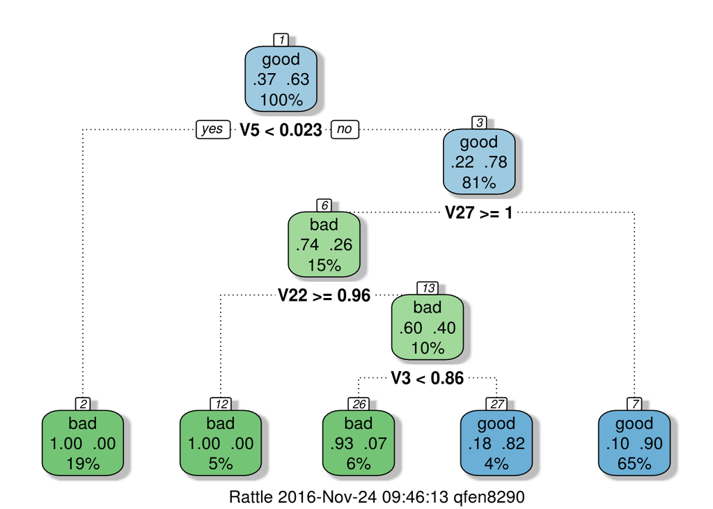

```r
library(RColorBrewer)

dt_model1 <- rpart(Class ~ ., data=df_train)
fancyRpartPlot(dt_model1)
```

```r
dt_pred1 <- predict(dt_model1, df_test, type="class")
```

### Model performance metrics

```r
dt_metrics1 <- classification_metrics(df_test$Class, dt_pred1, pos_label="good")
cat(c("Accuracy:", round(dt_metrics1$accuracy, digits = 3)))
```

```
## Accuracy: 0.924
```

```r
cat(c("Precision:", round(dt_metrics1$precision, digits = 3)))
```

```
## Precision: 0.897
```

```r
cat(c("Recall:", round(dt_metrics1$recall, digits = 3)))
```

```
## Recall: 1
```

```r
cat(c("F1 score:", round(dt_metrics1$F1_score, digits = 3)))
```

```
## F1 score: 0.946
```

## XGBoost model

```r
library(xgboost)
```

XGBoost only works with numeric vectors, so we need to convert the Class into numeric first.

```r
df_train_label <- df_train$Class == "good"
df_train_label
```

```
##   [1] FALSE FALSE  TRUE  TRUE FALSE  TRUE  TRUE  TRUE  TRUE FALSE  TRUE
##  [12]  TRUE FALSE  TRUE  TRUE  TRUE FALSE  TRUE FALSE  TRUE  TRUE  TRUE
##  [23] FALSE FALSE FALSE  TRUE  TRUE  TRUE  TRUE  TRUE FALSE  TRUE  TRUE
##  [34] FALSE  TRUE  TRUE FALSE FALSE FALSE FALSE  TRUE FALSE  TRUE FALSE
##  [45] FALSE  TRUE FALSE  TRUE  TRUE  TRUE  TRUE  TRUE  TRUE  TRUE  TRUE
##  [56] FALSE  TRUE FALSE  TRUE FALSE  TRUE FALSE FALSE FALSE FALSE FALSE
##  [67] FALSE  TRUE FALSE FALSE  TRUE  TRUE  TRUE  TRUE  TRUE  TRUE  TRUE
##  [78] FALSE FALSE  TRUE  TRUE FALSE  TRUE  TRUE FALSE FALSE FALSE  TRUE
##  [89]  TRUE FALSE  TRUE FALSE FALSE  TRUE  TRUE FALSE FALSE FALSE  TRUE
## [100]  TRUE FALSE  TRUE FALSE  TRUE FALSE  TRUE FALSE  TRUE FALSE FALSE
## [111]  TRUE  TRUE  TRUE FALSE FALSE FALSE FALSE  TRUE  TRUE FALSE  TRUE
## [122]  TRUE FALSE FALSE  TRUE  TRUE  TRUE  TRUE  TRUE  TRUE  TRUE  TRUE
## [133]  TRUE FALSE  TRUE  TRUE FALSE FALSE  TRUE  TRUE  TRUE  TRUE FALSE
## [144]  TRUE FALSE  TRUE FALSE  TRUE  TRUE FALSE  TRUE  TRUE FALSE FALSE
## [155] FALSE  TRUE  TRUE  TRUE  TRUE  TRUE  TRUE  TRUE  TRUE FALSE  TRUE
## [166]  TRUE FALSE FALSE  TRUE  TRUE FALSE  TRUE  TRUE  TRUE FALSE  TRUE
## [177]  TRUE  TRUE  TRUE  TRUE FALSE  TRUE  TRUE  TRUE  TRUE FALSE  TRUE
## [188]  TRUE FALSE  TRUE FALSE  TRUE  TRUE  TRUE  TRUE  TRUE FALSE  TRUE
## [199]  TRUE  TRUE  TRUE  TRUE FALSE  TRUE  TRUE FALSE FALSE  TRUE  TRUE
## [210]  TRUE  TRUE  TRUE  TRUE  TRUE FALSE  TRUE  TRUE FALSE  TRUE  TRUE
## [221]  TRUE  TRUE  TRUE FALSE  TRUE  TRUE FALSE FALSE FALSE FALSE  TRUE
## [232]  TRUE  TRUE  TRUE FALSE FALSE FALSE FALSE  TRUE  TRUE  TRUE FALSE
## [243]  TRUE  TRUE  TRUE  TRUE
```

```r
xgb_model1 <- xgboost(data=as.matrix(df_train[, -33]), label=df_train_label, nrounds=20, objective="binary:logistic", eta=0.3, max_depth=6)
xgb_pred1 <- predict(xgb_model1, as.matrix(df_test[, -33]))
xgb_pred1 <- ifelse(xgb_pred1 > 0.5, "good", "bad")
```

### Model performance metrics

```r
xgb_metrics1 <- classification_metrics(df_test$Class, xgb_pred1, pos_label="good")
cat(c("Accuracy:", round(xgb_metrics1$accuracy, digits = 3)))
```

```
## Accuracy: 0.924
```

```r
cat(c("Precision:", round(xgb_metrics1$precision, digits = 3)))
```

```
## Precision: 0.919
```

```r
cat(c("Recall:", round(xgb_metrics1$recall, digits = 3)))
```

```
## Recall: 0.971
```

```r
cat(c("F1 score:", round(xgb_metrics1$F1_score, digits = 3)))
```

```
## F1 score: 0.944
```

### Feature importance

```r
importance_matrix <- xgb.importance(feature_names=colnames(df_train[1, -33]), model=xgb_model1)
print(importance_matrix)
```

```
##     Feature         Gain       Cover   Frequence
##  1:      V5 2.459871e-01 0.115476800 0.075342466
##  2:      V3 1.528428e-01 0.147145286 0.116438356
##  3:     V33 1.310171e-01 0.065137808 0.020547945
##  4:     V27 1.211040e-01 0.058800235 0.027397260
##  5:     V22 8.075409e-02 0.066110662 0.075342466
##  6:     V14 5.184478e-02 0.125908069 0.109589041
##  7:      V8 4.348011e-02 0.056725177 0.061643836
##  8:      V6 4.300756e-02 0.111884351 0.102739726
##  9:     V34 3.273922e-02 0.077322140 0.061643836
## 10:     V24 2.060188e-02 0.036345003 0.041095890
## 11:     V20 1.455438e-02 0.016191717 0.027397260
## 12:     V25 8.577711e-03 0.013531045 0.013698630
## 13:     V29 8.147392e-03 0.018070725 0.034246575
## 14:      V7 7.293700e-03 0.011240771 0.027397260
## 15:     V21 7.253022e-03 0.015861484 0.034246575
## 16:      V4 5.335829e-03 0.014111507 0.020547945
## 17:     V15 4.615838e-03 0.004323418 0.013698630
## 18:     V23 3.840322e-03 0.007768809 0.020547945
## 19:      V9 3.671454e-03 0.007295122 0.020547945
## 20:     V12 3.531334e-03 0.003682606 0.020547945
## 21:     V26 3.047179e-03 0.005735505 0.013698630
## 22:     V11 2.455530e-03 0.003511861 0.013698630
## 23:     V18 2.234655e-03 0.003030521 0.013698630
## 24:     V31 9.950039e-04 0.003995575 0.006849315
## 25:     V28 5.500265e-04 0.001775606 0.006849315
## 26:     V16 4.787527e-04 0.001584123 0.006849315
## 27:     V10 3.044510e-05 0.004895782 0.006849315
## 28:     V17 8.816024e-06 0.002538294 0.006849315
##     Feature         Gain       Cover   Frequence
```

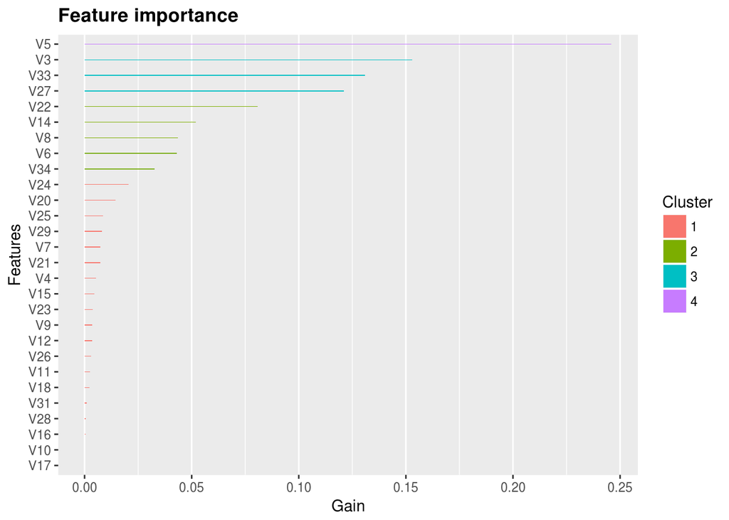

```r
xgb.plot.importance(importance_matrix)
```

## Random Forest

```r
library(randomForest)
rf_model1 <- randomForest(Class ~ ., data=df_train)
rf_pred1 <- predict(rf_model1, df_test)
```

### Model performance metrics

```r
rf_metrics1 <- classification_metrics(df_test$Class, rf_pred1, pos_label="good")
cat(c("Accuracy:", round(rf_metrics1$accuracy, digits = 3)))
```

```
## Accuracy: 0.943
```

```r
cat(c("Precision:", round(rf_metrics1$precision, digits = 3)))
```

```
## Precision: 0.957
```

```r
cat(c("Recall:", round(rf_metrics1$recall, digits = 3)))
```

```
## Recall: 0.957
```

```r
cat(c("F1 score:", round(rf_metrics1$F1_score, digits = 3)))
```

```
## F1 score: 0.957
```

# ROC (Receiver Operator Characteristic) Curve

ROC is a very powerful performance measurement for binary classification. Good classifiers have big area under the curve (AUC).

```r
library(ROCR)
```

```r
roc_plot <- function(truth, pred, ...) {
  roc_pred <- prediction(pred, truth)
  roc_perf <- performance(roc_pred, "tpr", "fpr")
  ROCR::plot(roc_perf, ...)
}
```

## Compare the ROC for different classifiers

[figure not shown]

```r
svm_fit1 <- svm(Class ~ ., data=df_train, kerenl="radial", type="C-classification", probability=TRUE)
svm_pred_prob <- predict(svm_fit1, df_test, probability=T)
svm_pred_prob <- attr(svm_pred_prob, "probabilities")[, "good"]

knn_pred_prob <- knn(train=df_train[, -33], test=df_test[, -33], cl=df_train$Class, k=3, prob=T)
knn_pred_prob <- attr(knn_pred_prob, "prob")

lda_fit <- lda(Class ~ ., data=df_train)
lda_pred_prob <- predict(lda_fit, df_test)$posterior[, "good"]

lr_fit <- glm(Class ~ ., data=df_train, family=binomial(link="logit"))
lr_pred_prob <- predict(lr_fit, df_test, type="response")

dt_fit <- rpart(Class ~ ., data=df_train)
dt_pred_prob <- predict(dt_fit, df_test, type="prob")[, "good"]

rf_fit <- randomForest(Class ~ ., data=df_train)
rf_pred_prob <- predict(rf_fit, df_test, type="prob")[, "good"]


roc_plot(df_test$Class, svm_pred_prob, col="red", lwd=2)
roc_plot(df_test$Class, knn_pred_prob, col="blue", lwd=2, add=T)
roc_plot(df_test$Class, lda_pred_prob, col="green", lwd=2, add=T)
roc_plot(df_test$Class, lr_pred_prob, col="purple", lwd=2, add=T)
roc_plot(df_test$Class, dt_pred_prob, col="black", lwd=2, add=T)
roc_plot(df_test$Class, rf_pred_prob, col="orange", lwd=2, add=T)
legend("bottomright", lty=1, lwd=1, legend=c("SVM", "kNN", "LDA", "Logistic Regression", "LDA", "Dicision Tree", "Random Forest"), col=c("red", "blue", "green", "purple", "black", "orange"))
```